# Busqueda por Amplitud

A continuacion se ejemplifica la busqueda por amplitud revisada en clase. Para ello se tiene un ejemplo de las ciudades del territorio Ecuatoriano.

### Autor: David Egas

## Resolución de ejercicio 1: ciudades

```python
# Busqueda en Amplitud - Breadth First Search
import networkx as nx
import matplotlib.pyplot as plt
# Creamos la clase Nodo
class Node:
    def __init__(self, data, child=None): # Constructor de la clase
        self.data = data
        self.child = None
        self.fathr = None
        self.cost = None
        self.set_child(child)

    def set_child(self, child): # Agregar hijos
        self.child = child
        if self.child is not None:
            for ch in self.child:
                ch.fathr = self

    def equal(self, node): # Igual al equals de Java
        if self.data == node.data:
            return True
        else:
            return False

    def on_list(self, node_list): # Verfiicar su el nodo esta en la lista
        listed = False
        for n in node_list:
            if self.equal(n):
                listed = True
        return listed

    def __str__(self): # Igual al toString Java
        return str(self.data)
```

```
------------------------------------------------------------------------------------------------------------
Los nodos camino son:
['Guayaquil', 'Ambato']
------------------------------------------------------------------------------------------------------------
------------------------------------------------------------------------------------------------------------
La imagen muestra el grafo completo y la ruta hacia la meta
------------------------------------------------------------------------------------------------------------
```

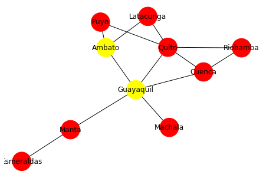

```
------------------------------------------------------------------------------------------------------------
La imagen muestra solo el camino
------------------------------------------------------------------------------------------------------------
```

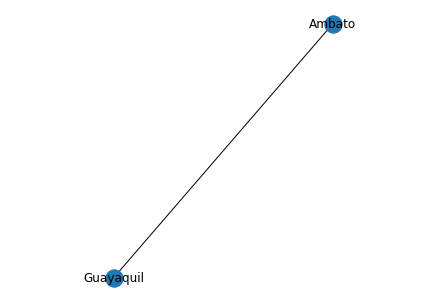

```
Nodos:  2 ['Guayaquil', 'Ambato']
Enlaces:  1 [('Guayaquil', 'Ambato')]
```

```python
# Implementacion del metodo de busqueda por amplitud
def search_Amplitud_solution(connections, init_state, solution):
    solved = False # Variable para almacenar el estado de la busqueda
    visited_nodes = [] # Nodos visitados
    frontrs_nodes = [] # Nodos en busqueda o lista nodos

    init_node = Node(init_state) # Nodo inicial
    frontrs_nodes.append(init_node)
    while (not solved) and len(frontrs_nodes) != 0:
        node = frontrs_nodes[0]
        # extraer nodo y añadirlo a visitados
        visited_nodes.append(frontrs_nodes.pop(0))
        if node.data == solution: # Preguntar se el nodo obtenido es la solucion
            solved = True
            return node # Retornamos el nodo de la solucion
        else:
            # expandir nodos hijo - ciudades con conexion
            node_data = node.data
            child_list = []
            for chld in connections[node_data]:
                child = Node(chld)
                child_list.append(child)
                if not child.on_list(visited_nodes) and not child.on_list(frontrs_nodes):
                    frontrs_nodes.append(child)
            node.set_child(child_list)


def graficar(init_state, result):
    G=nx.Graph()

    result.remove(init_state)

    G.add_node(init_state)
    for n in result:
        G.add_edge(n, init_state)
        init_state = n


    nx.draw(G,with_labels=True)
    plt.show()

    print ("Nodos: ", G.number_of_nodes(), G.nodes())
    print ("Enlaces: ", G.number_of_edges(),G.edges())

if __name__ == "__main__":
    connections = {
        'Cuenca': {'Riobamba', 'Quito', 'Guayaquil'},
        'Latacunga': {'Ambato', 'Quito'},
        'Esmeraldas': {'Manta'},
        'Manta': {'Guayaquil'},
        'Quito': {'Riobamba', 'Latacunga', 'Cuenca', 'Guayaquil', 'Puyo'},
        'Riobamba': {'Cuenca', 'Quito'},
        'Ambato': {'Latacunga', 'Puyo', 'Guayaquil'},
        'Puyo': {'Ambato', 'Quito'},
        'Machala': {'Guayaquil'},
        'Guayaquil': {'Machala', 'Ambato', 'Quito', 'Cuenca', 'Manta'}
    }

    init_state = 'Guayaquil'
    solution = 'Ambato'
    solution_node = search_Amplitud_solution(connections, init_state, solution)
    # mostrar resultado
    result = []
    node = solution_node
    if node is not None:
        while node.fathr is not None:
            result.append(node.data)
            node = node.fathr
        result.append(init_state)
        result.reverse() # Reverso el resultado (Solo para presentar)
        print("------------------------------------------------------------------------------------------------------------")
        print ("Los nodos camino son:")
        print(result)
        print("------------------------------------------------------------------------------------------------------------")
    else:
        print("No hay solucion !!!!")



    G=nx.Graph()
    G.add_nodes_from(connections.keys()) #se cargan todos los nodos

    keys= connections.keys() # Se guardan las llaves para compararlas
    color_map = [] # colores aplicados

    for r in keys:

        if r in result:

            color_map.append('yellow')

        else:

            color_map.append('red')

    for k, v in connections.items():
        G.add_edges_from(([(k, t) for t in v]))#se cargan los enlaces


    print("------------------------------------------------------------------------------------------------------------")
    print ("La imagen muestra el grafo completo y la ruta hacia la meta")
    print("------------------------------------------------------------------------------------------------------------")
    nx.draw(G,node_color=color_map, with_labels=True, node_size=1000)
    plt.show()

    print("------------------------------------------------------------------------------------------------------------")
    print ("La imagen muestra solo el camino")
    print("------------------------------------------------------------------------------------------------------------")
    graficar(init_state, result)
```

## Resolución de ejercicio 2: hospitales

### Mapa de niveles

[figure not shown]

```python
# Busqueda en Amplitud - Breadth First Search
import networkx as nx
import matplotlib.pyplot as plt
# Creamos la clase Nodo
class Node:
    def __init__(self, data, child=None): # Constructor de la clase
        self.data = data
        self.child = None
        self.fathr = None
        self.cost = None
        self.set_child(child)

    def set_child(self, child): # Agregar hijos
        self.child = child
        if self.child is not None:
            for ch in self.child:
                ch.fathr = self

    def equal(self, node): # Igual al equals de Java
        if self.data == node.data:
            return True
        else:
            return False

    def on_list(self, node_list): # Verfiicar su el nodo esta en la lista
        listed = False
        for n in node_list:
            if self.equal(n):
                listed = True
        return listed

    def __str__(self): # Igual al toString Java
        return str(self.data)
```

```
------------------------------------------------------------------------------------------------------------
Los nodos camino son:
['MiCasa', 'Centro de Salud Materno Infantil - IESS', 'Hospital Universitario Católico', 'Clínica Praxxel', 'Hospital Bolívar', 'Clínica Latino', 'Clínica Humanitaria']
------------------------------------------------------------------------------------------------------------
------------------------------------------------------------------------------------------------------------
La imagen muestra el grafo completo y la ruta hacia la meta
------------------------------------------------------------------------------------------------------------
```

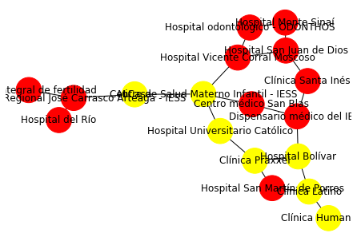

```
------------------------------------------------------------------------------------------------------------
La imagen muestra solo el camino
------------------------------------------------------------------------------------------------------------
```

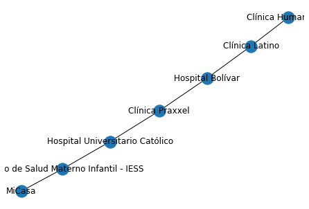

[output not shown]

```python
# Implementacion del metodo de busqueda por amplitud

def search_Amplitud_solution(connections, init_state, solution):
    solved = False # Variable para almacenar el estado de la busqueda
    visited_nodes = [] # Nodos visitados
    frontrs_nodes = [] # Nodos en busqueda o lista nodos


    init_node = Node(init_state) # Nodo inicial
    frontrs_nodes.append(init_node)



    color_map = []
    while (not solved) and len(frontrs_nodes) != 0:
        node = frontrs_nodes[0]

        # extraer nodo y añadirlo a visitados
        visited_nodes.append(frontrs_nodes.pop(0))
        if node.data == solution: # Preguntar se el nodo obtenido es la solucion
            solved = True



            return node # Retornamos el nodo de la solucion
        else:
            # expandir nodos hijo - ciudades con conexion
            node_data = node.data
            child_list = []



            for chld in connections[node_data]:
                child = Node(chld)
                child_list.append(child)

                if not child.on_list(visited_nodes) and not child.on_list(frontrs_nodes):
                    frontrs_nodes.append(child)


            node.set_child(child_list)


def graficar(init_state, result):
    G=nx.Graph()

    result.remove(init_state)

    G.add_node(init_state)
    for n in result:
        G.add_edge(n, init_state)
        init_state = n


    nx.draw(G,with_labels=True)
    plt.show()

    print ("Nodos: ", G.number_of_nodes(), G.nodes())
    print ("Enlaces: ", G.number_of_edges(),G.edges())



if __name__ == "__main__":
    connections = {
        'MiCasa': {'Hospital Regional José Carrasco Arteaga - IESS','Centro de Salud Materno Infantil - IESS'},
        'Hospital Regional José Carrasco Arteaga - IESS': {'Unidad integral de fertilidad','Hospital del Río', 'MiCasa'},
        'Unidad integral de fertilidad': {'Hospital Regional José Carrasco Arteaga - IESS'},
        'Hospital del Río': {'Hospital Regional José Carrasco Arteaga - IESS'},
        'Centro de Salud Materno Infantil - IESS':{'Hospital Vicente Corral Moscoso','Centro médico San Blas','Hospital Universitario Católico', 'MiCasa'},
        'Hospital Vicente Corral Moscoso':{'Centro de Salud Materno Infantil - IESS','Hospital odontológico - ODONTHOS','Hospital San Juan de Dios'},
        'Centro médico San Blas': {'Centro de Salud Materno Infantil - IESS','Dispensario médico del IESS'},
        'Hospital Universitario Católico':{'Clínica Praxxel','Centro de Salud Materno Infantil - IESS'},
        'Hospital odontológico - ODONTHOS':{'Hospital Monte Sinaí','Hospital Vicente Corral Moscoso'},
        'Hospital San Juan de Dios':{'Hospital Monte Sinaí','Hospital Vicente Corral Moscoso'},
        'Dispensario médico del IESS':{'Clínica Santa Inés','Hospital Bolívar','Centro médico San Blas'},
        'Clínica Praxxel':{'Hospital Bolívar','Hospital San Martín de Porres','Hospital Universitario Católico'},
        'Hospital San Martín de Porres':{'Clínica Praxxel','Clínica Latino'},
        'Hospital Bolívar':{'Clínica Latino','Dispensario médico del IESS'},
        'Clínica Santa Inés':{'Hospital San Juan de Dios'},
        'Hospital Monte Sinaí':{'Hospital odontológico - ODONTHOS'},
        'Clínica Latino':{'Hospital San Martín de Porres','Hospital Bolívar','Clínica Humanitaria'},
        'Clínica Humanitaria':{'Clínica Latino'}
    }

    init_state = 'MiCasa'
    solution = 'Clínica Humanitaria'
    solution_node = search_Amplitud_solution(connections, init_state, solution)
    # mostrar resultado
    result = []
    node = solution_node

    if node is not None:
        while node.fathr is not None:
            result.append(node.data)
            node = node.fathr
        result.append(init_state)
        result.reverse() # Reverso el resultado (Solo para presentar)
        print("------------------------------------------------------------------------------------------------------------")
        print ("Los nodos camino son:")
        print(result)
        print("------------------------------------------------------------------------------------------------------------")
    else:
        print("No hay solucion !!!!")



    G=nx.Graph()
    G.add_nodes_from(connections.keys()) #se cargan todos los nodos

    keys= connections.keys() # Se guardan las llaves para compararlas
    color_map = [] # colores aplicados

    for r in keys:

        if r in result:

            color_map.append('yellow')

        else:

            color_map.append('red')

    for k, v in connections.items():
        G.add_edges_from(([(k, t) for t in v]))#se cargan los enlaces


    print("------------------------------------------------------------------------------------------------------------")
    print ("La imagen muestra el grafo completo y la ruta hacia la meta")
    print("------------------------------------------------------------------------------------------------------------")
    nx.draw(G,node_color=color_map, with_labels=True, node_size=1000)
    plt.show()

    print("------------------------------------------------------------------------------------------------------------")
    print ("La imagen muestra solo el camino")
    print("------------------------------------------------------------------------------------------------------------")
    graficar(init_state, result)
```

# Tarea: Cálculo del factor de ramificación

Realice el cálculo del factor de ramificación del problema de las N reinas (con N = 4). Para ello deberá realizar las siguientes actividades:

Asumir que el factor de ramificación es constante. Despejar el valor de b Consultar sitios externos sobre cómo realizar el cálculo

### Solución:

#### Fórmula del factor de ramificación:

###### La ecuación inicial donde n = 4, d = 4

\begin{equation*} n=\frac{b^{d+1}-1}{b-1}\\ \end{equation*}

###### reemplazamos los valores

\begin{equation*} 4=\frac{b^{4+1}-1}{b-1}\\ \end{equation*}\begin{equation*} 4=\frac{b^5-1}{b-1} \end{equation*}\begin{equation*} 4=\frac{\left(b-1\right)\left(b^4+b^3+b^2+b+1\right)}{b-1} \end{equation*}\begin{equation*} 4=b^4+b^3+b^2+b+1 \end{equation*}\begin{equation*} b^4+b^3+b^2+b+1=4 \end{equation*}

###### obtenemos una ecuación que sera resuelta por Newton-Raphson

\begin{equation*} b^4+b^3+b^2+b-3 \end{equation*}\begin{equation*} \frac{d}{db}\left(b^4+b^3+b^2+b-3\right) \end{equation*}\begin{equation*} \frac{d}{db}\left(b^4+b^3+b^2+b-3\right) \end{equation*}

###### Obtenemos que el factor de ramificación es de:

\begin{equation*} b\approx \:0.88817\dots \end{equation*}

## Practica

Implementar un algoritmo que me permita dibujar las conexiones y los resultados del grafo.

Mediante el uso de la herramienta de Google Maps tomar al su direccion domiciliaria como punto de partida y generar un arbol jerarquico con todos los posibles Hospitales, para ello se debe tener como primer nivel los mas cercanos y a continuacion los demas.

Realizar los calculos para obtener el factor de ramificacion, análisis del algoritmo en términos de completitud, optimalidad, complejidad temporal y complejidad espacial.

Subir el cuaderno con la resolucion

# Implementar

## Cálculos del grafo de hospitales:

### Factor de Ramificación:

Donde n = 18 (nodos) y d = 6 (profundidad)

\begin{equation*} b\approx \:1.30763\dots \end{equation*}

### Completitud

Si cumple con esto, ya que todos los nodos son expandidos para realizar la búsqueda

### Optimalidad

En ningún caso asegura la optimalidad, pues puede encontrar una solución más profunda que otra en una rama que todavía no ha sido expandida.